# M2: Assignment 2

**Loading packages**

```r
rm(list = ls()) # Clearing the environment
options(scipen=999) # No scientific notations
library(tidyverse)
library(tidytext)
library(tidymodels)
library(textdata)
library(textrecipes)
library(magrittr)
library(SnowballC)
library(topicmodels)
library(tm)
library(spacyr)
```

## 1 Preprocessing and vectorization

*Loading the data*

```r
tmp <- tempfile()
download.file("https://github.com/SDS-AAU/SDS-2020/raw/master/M2/assignments/data/twitter_hate.zip", tmp)
tweets <- read.csv(unzip(tmp)) # Reading the unzipped file.
```

Let’s inspect the data.

```r
tweets %>% glimpse()
```

```
## Rows: 24,783
## Columns: 3
## $ X     <int> 0, 1, 2, 3, 4, 5, 6, 7, 8, 9, 10, 11, 12, 13, 14, 15, 16, 17,...
## $ class <int> 2, 1, 1, 1, 1, 1, 1, 1, 1, 1, 1, 1, 1, 1, 1, 1, 1, 1, 1, 1, 1...
## $ tweet <chr> "!!! RT @mayasolovely: As a woman you shouldn't complain abou...
```

The dataset consists of 24.783 rows, where each row contains a tweet from the person in column “X”. The “class” column classifies if the tweet is: 0 - hate speech, 1 - offensive language, 2 - neither. In order to be able to predict these classes, the “noise” in the tweets needs to be reduced. It is a question of removing elements that are not important for the general meaning of the sentence. Let’s check some examples of tweets. For this I will be filtering for tweets containing ‘http’, to only view tweets containing hyperlinks. This is to have a frame of reference, as I will be removing the links from the tweets later.

```r
tweet_example <- tweets %>% # Saving the tweets, since the filter will not be applicable once the links are removed.
  filter((tweet %>% str_detect('http'))) %>% # Only displaying tweets containing hyperlinks.
  slice(5:14) # Printing rows 5-14 as these were relevant.

tweet_example %>% select(tweet) %>% print()
```

```
##                                                                                                                                      tweet
## 1          "@ARIZZLEINDACUT: Females think dating a pussy is cute now? http://t.co/VxBJg26Gsz" how does doing this stuff make him a pussy?
## 2                                                  "@Addicted2Guys: -SimplyAddictedToGuys http://t.co/1jL4hi8ZMF" woof woof hot scally lad
## 3                                                                       "@AllAboutManFeet: http://t.co/3gzUpfuMev" woof woof and hot soles
## 4  "@Almightywayne__: @JetsAndASwisher @Gook____ bitch fuck u http://t.co/pXmGA68NC1" maybe you'll get better. Just http://t.co/TPreVwfq0S
## 5                                                  "@AutoWorId: Hennessey Venom GT &#128584; http://t.co/i8eGMnKaJ9" that's one sexy bitch
## 6         "@BVSEDCHINK: Yo fuck skateboarding, all y'all some wood pushing faggots man, ball is life http://t.co/VBCzP6HMT7"\n@AmJemieBenn
## 7                                          "@BabyAnimalPics: baby monkey bathtime http://t.co/7KPWAdLF0R"\nAwwwwe! This is soooo ADORABLE!
## 8                                                          "@BeenBasedB: @_KudaBrazyy http://t.co/LuUBGL9Y5u" 0 rings 0 mvps 0 bitches lol
## 9                      "@BestProAdvice: The facts on tattoos...tattoo http://t.co/ZwnbhpDZ8e" he's a pussy with not tattooing them nipples
## 10                                                                 "@BitchJones92: Get worshiping bitch! http://t.co/R37CejCjou" woof woof
```

There are clearly a lot of special characters, questionable spellings and swearwords. It is also worth noting that there are occurrences of people missing spacing after their full-stop. When the ‘.’ is removed this will result in the two words joining and creating a new gibberish word, i.e. “tattoostattoo”, which often will not make any sense. To try to minimize this, I will replace dots by empty spaces by substituting globally using *str_replace_all* from **stringr**. This doesn’t solve missing spaces in other cases, but let’s have some faith in peoples ability to have correct spacing between their words and special characters. This does create a space in every hyperlink however, which makes it problematic to remove later, so I will be removing all links from the tweets first. Lastly, from trial and error I found that @ following a quotationmark would be removed, which means that these nametags could not be found by searching for @ symbols later. An easy fix for this is to replace all quotationmarks with a whitespace.

```r
tweets$tweet %<>% str_replace_all('http\\S+\\s*', "") %>% # First removing all following non-whitespace characters after http.
  str_replace_all('\\.',' ') %>% # Then replacing dots with whitespaces.
  str_replace_all('\\"',' ') # Replacing quotationmarks with a whitespace.
```

Let’s check how the tweets from before look after removing links and adding whitespace instead of dots.

```r
tweets %>%
  filter(X %in% tweet_example$X) %>% # Filtering for the X values that are in tweet_example, to get the same tweets as before.
  select(tweet)
```

| tweet |
| --- |
| @ARIZZLEINDACUT: Females think dating a pussy is cute now? how does doing this stuff make him a pussy? |
| @Addicted2Guys: -SimplyAddictedToGuys woof woof hot scally lad |
| @AllAboutManFeet: woof woof and hot soles |
| @Almightywayne__: @JetsAndASwisher @Gook____ bitch fuck u maybe you'll get better Just |
| @AutoWorId: Hennessey Venom GT &#128584; that's one sexy bitch |
| @BVSEDCHINK: Yo fuck skateboarding, all y'all some wood pushing faggots man, ball is life @AmJemieBenn |
| @BabyAnimalPics: baby monkey bathtime Awwwwe! This is soooo ADORABLE! |
| @BeenBasedB: @_KudaBrazyy 0 rings 0 mvps 0 bitches lol |
| @BestProAdvice: The facts on tattoos tattoo he's a pussy with not tattooing them nipples |
| @BitchJones92: Get worshiping bitch! woof woof |

Looks like the links have been removed succesfully, and the fullstops are replaced by whitespaces.

Next I will be “tokenizing” the tweets, which breaks the strings of text up into tokens of one word each. Each word is then easily accessible as it has it’s own row. This essentially creates the bag-of-word representation. To perform the tokenization I will be using *unnest_tokens* from **tidytext**, which also makes every letter lower-case, and removes all special characters. I will be using the argument token = “tweets”, which preserves usernames and hashtags, so they can be manipulated later. As the tweets contain a lot of unnecessary words, I will also be removing “stopwords”, which are frequent and mostly unimportant for the overall meaning of the tweet. These stopwords comes from a stopword lexicon from **tidytext**, which is called by *stop_words*. Practically this is accomplished by anti-joining the wordlist by the stopword lexicon. Thereby the wordlist will only have words that are not in the stopword lexicon. An alternate to this could be to keep all the stopwords, and instead use them to identify bi and tri grams (phrases of 2 and 3 words), and using these phrases to predict the next word. The data is full of slang and other improper grammar, which would probably create inconsistent n-grams, and thereby make it harder to predict the next words. Furthermore, I think there are certain words that see more usage in hate speech than the other two categories, i.e. slurs, which will be more useful for the categorization, than the phrase they are contained in.

Lastly I try to apply stemming to the words, to generalize the words more and hopefully make the bag-of-words representation and TF-IDF more accurate. This way the same word is not counted in multiple ways because of different endings to the word. To “stem” the words in the tweets I use the *wordStem* function from **SnowballC**, which collapses words to a common root.

```r
tweets_tidy <- tweets %>% # Creating the new dataframe of tidy tweets.
  unnest_tokens(word, tweet, token = "tweets") %>% # Tokenizing the tweets.
  anti_join(stop_words, by = 'word') %>%  # Removing stop-words.
  mutate(wordstem = wordStem(word)) # Stemming the words.
```

```r
tweets_tidy %>% filter(X %in% tweet_example$X) %>%
  head(20)
```

|  | X | class | word | wordstem |
| --- | --- | --- | --- | --- |
| 1 | 62 | 1 | @arizzleindacut | @arizzleindacut |
| 2 | 62 | 1 | females | femal |
| 3 | 62 | 1 | dating | date |
| 4 | 62 | 1 | pussy | pussi |
| 5 | 62 | 1 | cute | cute |
| 6 | 62 | 1 | stuff | stuff |
| 7 | 62 | 1 | pussy | pussi |
| 8 | 63 | 2 | @addicted2guys | @addicted2gui |
| 9 | 63 | 2 | simplyaddictedtoguys | simplyaddictedtogui |
| 10 | 63 | 2 | woof | woof |

[output cut: 10 more lines]

The first three of the tweets have been reduced to 19 words. The nametags mentioned still have their @, meaning they can easily be dropped in the future. The same is true for hashtags. Another thing that could be omitted are retweets and mentions. Retweets are now marked by tweets starting with “rt”. These could be dropped but retweets are still classified as hate speech, offensive language or neither, and seeing how we only have a number to identify the person with anyway, the originator of the tweet is not really important. As it is not a question of identifying who is tweeting hate-speech, I will be keeping the retweets, and removing all “rt” from the word column. The same argument can be applied to mentions, which were previously marked by quotationmarks. Let’s check our most popular words.

```r
tweets_tidy %>%
  count(word, sort = TRUE) %>%
  head(50)
```

|  | word | n |
| --- | --- | --- |
| 1 | bitch | 8179 |
| 2 | rt | 7590 |
| 3 | bitches | 3060 |
| 4 | hoes | 2350 |
| 5 | pussy | 2083 |
| 6 | im | 2080 |
| 7 | hoe | 1888 |
| 8 | dont | 1757 |
| 9 | ass | 1560 |
| 10 | fuck | 1417 |

[output cut: 40 more lines]

A very popular word in the tweets have turned out to be “amp” which originates from the HTML representation of &, which is &amp. This could be recoded as “and”, but as we are trying to get ridden of stopwords, I will simply drop it. 128514 also turned out be a popular “word”. This probably refers to an emoji. All in all, there is not much meaning to be found from including digits, since I imagine it is the minority of users, if any, that are writing their tweets using leetspeak, which is why I remove all digits from the words. I also drop the nametags, as it is not of importance who is talking to who, but merely what is being said.

```r
tweets_tidy %<>%
  filter(!(word %>% str_detect("amp|rt|@|[:digit:]"))) # Filtering out words containing amp, rt, @ or digits.
```

Let’s see if the filter worked.

```r
tweets_tidy %>%
  count(wordstem, sort = TRUE) %>%
  head(50)
```

|  | wordstem | n |
| --- | --- | --- |
| 1 | bitch | 11255 |
| 2 | hoe | 4242 |
| 3 | fuck | 2248 |
| 4 | pussi | 2187 |
| 5 | im | 2080 |
| 6 | nigga | 1988 |
| 7 | dont | 1760 |
| 8 | ass | 1577 |
| 9 | shit | 1295 |
| 10 | aint | 1160 |

[output cut: 40 more lines]

It did. Now our top words are looking neat and offensive.

Next step is to calculate TF-IDF. TF-IDF or Term Frequency - Inverse Document Frequency, is a way of weighing the words by their importance. This is attempted by increasing the importance the more times the word appears in a document (which would be a tweet in our case), but is penalized more if it occurs more frequently in the corpus, i.e. all the documents. This could normally be effective at reducing the importance of stop-words in sentences. I add TF-IDF and the TF-IDF weighted count to the corpus.

```r
tweets_tidy %<>%
  group_by(class) %>%
  add_count(X, wordstem) %>% # Adding a column which counts how many times a word appears per class.
  bind_tf_idf(term = wordstem,
              document = X,
              n = n) %>%  # Adding TF-IDF.
  add_count(wordstem, wt = tf_idf, name = "weighted_count") %>%  # Adding a TF-IDF weighted count.
  ungroup()
```

Let’s see how it looks.

```r
tweets_tidy %>% filter(X < 20) %>%  slice(16:25)
```

| X | class | word | wordstem | n | tf | idf | tf_idf | weighted_count |
| --- | --- | --- | --- | --- | --- | --- | --- | --- |
| 2 | 1 | dawg | dawg | 1 | 0.1666667 | 6.3558654 | 1.0593109 | 38.23049 |
| 2 | 1 | fuck | fuck | 1 | 0.1666667 | 2.3992693 | 0.3998782 | 868.76514 |
| 2 | 1 | bitch | bitch | 1 | 0.1666667 | 0.7884977 | 0.1314163 | 2035.95271 |
| 2 | 1 | cry | cry | 1 | 0.1666667 | 5.4165851 | 0.9027642 | 87.56707 |
| 2 | 1 | confused | confus | 1 | 0.1666667 | 6.6205579 | 1.1034263 | 27.33679 |
| 2 | 1 | shit | shit | 1 | 0.1666667 | 2.9507995 | 0.4917999 | 568.03677 |
| 3 | 1 | tranny | tranni | 1 | 1.0000000 | 6.1097323 | 6.1097323 | 42.72938 |
| 4 | 1 | shit | shit | 1 | 0.1428571 | 2.9507995 | 0.4215428 | 568.03677 |
| 4 | 1 | hear | hear | 1 | 0.1428571 | 5.7103463 | 0.8157638 | 46.66322 |
| 4 | 1 | true | true | 1 | 0.1428571 | 5.9123729 | 0.8446247 | 47.22395 |

Here we see the most frequent words, have the lowest TF-IDF values. Clearly Using TF-IDF as weights had a big influence.

### Document-Term Matrix

For my dimensionality reduction I will attempt to apply topic modelling to the tokens. I use *cast_dtm* from **tidytext**, to turn the dataframe of one word per row into a document-term matrix.

```r
tweets_dtm <- tweets_tidy %>%
  cast_dtm(document = X, term = wordstem, value = n) # Document-term matrix with tweet ID's as documents and terms = stems of words.
```

Next I remove noise in the matrix by removing terms more sparse than a certain threshold. I will find this threshold by trial and error. For removing the terms I use *removeSparseTerms* from **tm**.

```r
tweets_dtm %>% removeSparseTerms(sparse = .999)
```

```
## <<DocumentTermMatrix (documents: 24762, terms: 819)>>
## Non-/sparse entries: 95087/20184991
## Sparsity           : 100%
## Maximal term length: 28
## Weighting          : term frequency (tf)
```

Removing terms more sparse than 99.9% results in 819 unique terms out of the 15886 possible terms, which seems a bit too restrictive.

```r
tweets_dtm %>% removeSparseTerms(sparse = 0.9999)
```

```
## <<DocumentTermMatrix (documents: 24762, terms: 4911)>>
## Non-/sparse entries: 125580/121480602
## Sparsity           : 100%
## Maximal term length: 28
## Weighting          : term frequency (tf)
```

A sparsity threshold of 99.99% leaves 4911 unique terms, which is not too restrictive. It clearly removes a lot of words that do not see a lot of usage, which might be misspellings and things people generally never say, which will not be helpful for predicting anything.

Removing terms more sparse than 99.99%.

```r
tweets_dtm %<>% removeSparseTerms(sparse = 0.9999)
```

Before I can use the document term matrix I need to filter out the empty rows, where the words used to be. This is done by utilizing *unique* to find rows where there are different entries, i.e. not blank rows, and subsetting the dtm by them.

```r
uni = unique(tweets_dtm$i)
tweets_dtm_new = tweets_dtm[uni,] # Subsetting the document term matrix by the rows containing entries.
```

### Topic Modelling

Seeing how there are three different classes to predict, it makes sense to me to create three topics. This is accomplished using Latent Dirichlet Allocation (LDA) model. This is a topic modelling algorithm, which breaks down documents into a prespecified number of topics while finding the words that make up the topics. Topics in our case could be hate speech, offensive language or neither. I will therefore be applying the algorithm assuming three topics.

```r
tweets_lda <- tweets_dtm_new %>%
  LDA(k = 3, method = "Gibbs", # Assuming 3 topics and using Gibbs sampling.
      control = list(seed = 42))
```

To inspect the results, the $\beta$ values are saved. The $\beta$ measures the probability of a word appearing in a topic.

```r
lda_beta <- tweets_lda %>%
  tidy(matrix = "beta") %>%
  group_by(topic) %>% # Grouping the following operations by topic.
  arrange(topic, desc(beta)) %>%
  slice(1:10) %>% # Saving the first 10 beta values pr. topic.
  ungroup()
```

Let’s see if the words are separated nicely into the topics. To do this I will plot the 10 words with the highest $\beta$ values per topic.

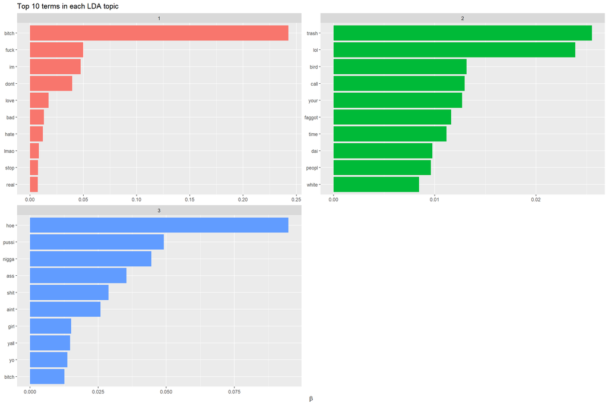

```r
lda_beta %>%
  mutate(term = reorder_within(term, beta, topic)) %>% # Reordering the term column prior to the plot.
  group_by(topic, term) %>%
  arrange(desc(beta)) %>%
  ungroup() %>%
  ggplot(aes(term, beta, fill = as.factor(topic))) + # Plotting the terms and coloring by topic.
  geom_col(show.legend = FALSE) +
  coord_flip() +
  scale_x_reordered() +
  labs(title = "Top 10 terms in each LDA topic",
       x = NULL, y = expression(beta)) +
  facet_wrap(~ topic, ncol = 2, scales = "free") # Generating a plot for each topic.
```

It seems none of the topics are void of offensive language, but if one were to compare, topic 1 seems the mildest of them. Based on the top $\beta$ values it seems that topic 2 is most likely to contain hate speech, seeing how one of the top words is trash, which is often used in a racist context in conjunction with white. Furthermore the homophobic slur “faggot” is also one of the more probably terms in the topic. “nigga” in topic 3 sees pretty wide usage, while it might have a racist origin, it is not always used in a hate speech context, and is in fact very commonly used in tweets from class 1, which are just containing generally offensive language.

## 2 Explore and compare hate speech vs offensive language

Let’s start by counting the amount of words belonging to each of the classes.

```r
tweets_tidy %>% count(class)
```

| class | n |
| --- | --- |
| 0 | 8688 |
| 1 | 109332 |
| 2 | 26348 |

8688 words were uttered in tweets that can be classified as hate speech, 109332 in tweets using offensive language, and 26348 words were neither. This is helpful for later, as a model that tries to maximize accuracy could have an accuracy above 75% if it predicts the class 1 every time, which would not be a great model. Let’s see the top 10 words for the three classes. For this I will be using a percentage based approach, since simply counting the number of occurences of the words would heavily favor class 1, as this class has the most words. If a word has a relatively high frequency in one class, compared to the corpus, that would indicate that it is more likely to be found within the class. To accomplish this I first count how many times a word occurs in the corpus, and then I count how many times the word is used within each of the classes. I then use these counts to create a new column which measures the percentage of the total count which originates from tweets of the given class.

```r
word_count <- tweets_tidy %>%
  select(wordstem, class, weighted_count) %>%  # Only selecting words, class and weighted count for this exercise.
  add_count(wordstem) %>%  # Total count of words.
  group_by(class) %>% # Grouping the following by class.
  add_count(wordstem) %>% # Counting occurences within the class.
  ungroup() %>% # Ungrouping for good measure.
  set_colnames(c("word", "class", "weighted_count", "corpus_count", "within_class_count")) %>%
  mutate(pct = within_class_count/corpus_count) # Creating a % variable.
```

Let’s start with inspecting the hate speech words. Here I am looking for words that occur within the class more than 6 % of the time, as that would indicate they are more likely to be in class 0, due to the size of the classes. If a word is used twice in the class and never again that would yield a percentage of 100, which is not too interesting, as I am looking for more generalizable results. For this reason I only select words that occur within the class more than 50 times. I am only interested in seeing one of each word per class, and will therefore be using *distinct* on the words, to only have unique words.

```r
word_count %>%
  filter(class == 0) %>%
  distinct(word, .keep_all = TRUE) %>%  # Selecting one of each word.
  filter(within_class_count > 50) %>% # Only viewing words that occur within the class more than 50 times.
  arrange(desc(pct)) %>%
  head(20)
```

| word | class | weighted_count | corpus_count | within_class_count | pct |
| --- | --- | --- | --- | --- | --- |
| nigger | 0 | 168.37014 | 323 | 166 | 0.51393189 |
| faggot | 0 | 266.95776 | 513 | 236 | 0.46003899 |
| fag | 0 | 187.05806 | 277 | 107 | 0.38628159 |
| white | 0 | 87.06053 | 380 | 128 | 0.33684211 |
| retard | 0 | 74.08269 | 394 | 63 | 0.15989848 |
| peopl | 0 | 35.43490 | 425 | 59 | 0.13882353 |
| hate | 0 | 51.00935 | 534 | 69 | 0.12921348 |
| your | 0 | 57.80454 | 561 | 62 | 0.11051693 |
| nigga | 0 | 90.31829 | 1988 | 213 | 0.10714286 |
| trash | 0 | 71.10819 | 1140 | 113 | 0.09912281 |

[output cut: 8 more lines]

Let’s check the other classes. For the tweets that use offensive language, I only look at the words that occur more than 500 times within the class, since the class is much larger.

```r
word_count %>%
  filter(class == 1) %>%
  distinct(word, .keep_all = TRUE) %>%
  filter(within_class_count > 500) %>%
  arrange(desc(pct)) %>%
  head(20)
```

| word | class | weighted_count | corpus_count | within_class_count | pct |
| --- | --- | --- | --- | --- | --- |
| bitch | 1 | 2035.9527 | 11255 | 10980 | 0.9755664 |
| pussi | 1 | 1242.0056 | 2187 | 2128 | 0.9730224 |
| hoe | 1 | 1780.6762 | 4242 | 4103 | 0.9672324 |
| shit | 1 | 568.0368 | 1295 | 1228 | 0.9482625 |
| aint | 1 | 576.5718 | 1160 | 1092 | 0.9413793 |
| yo | 1 | 333.9378 | 610 | 566 | 0.9278689 |
| bad | 1 | 390.3238 | 568 | 518 | 0.9119718 |
| ass | 1 | 607.9783 | 1577 | 1437 | 0.9112238 |
| fuck | 1 | 868.7651 | 2248 | 2026 | 0.9012456 |
| yall | 1 | 350.9774 | 658 | 591 | 0.8981763 |

[output cut: 6 more lines]

The percentages serve less of a purpose now, as most of the words can be found in class 1, but there is a very distinct difference from the previous table. The weighted counts also indicate that the 3 top words are less important than their within class count would indicate. There is definitely large differences between the classes. Outside of the top words in class 0, it might be difficult to distinguish between class 0 and 1, since many of the words also see use outside of a hate speech context.

### Class specific themes

To identify themes/topics that are specific for one class or another I will be trying to gain an overview using the $\beta$ values from the LDA model.

```r
topic_count <- tweets_lda %>%
  tidy(matrix = "beta") %>%
  group_by(topic) %>% # Grouping the following operations by topic.
  arrange(topic, desc(beta)) %>%
  ungroup() %>%
  left_join(word_count, by = c("term" = "word")) %>% # Joining terms by the column word in word_count.
  filter(class < 2) # There is no need for the class 2 words for now.
```

I will be summing the betas by class and topic, to find a cumulative probability of the topic in each of the classes, and hopefully distinguish some differences between the topics.

```r
topic_count %>%
  distinct(term, topic, .keep_all = TRUE) %>% # Finding distinct words in each topic.
  group_by(class, topic) %>%
  summarise(sum_beta = sum(beta))
```

| class | topic | sum_beta |
| --- | --- | --- |
| 0 | 1 | 0.02910099 |
| 0 | 2 | 0.07299943 |
| 0 | 3 | 0.03197415 |
| 1 | 1 | 0.96634165 |
| 1 | 2 | 0.91975520 |
| 1 | 3 | 0.96454576 |

To try and gain some insights using the top TF-IDF words, I right join the topic_count dataframe with the 20 words with the highest TF-IDF weighted count. I then sort by descending $\beta$ values and print the top 5 for each topic. I use group_by to check the beta values of all the top words in each topic.

```r
topic_count %>%
  group_by(topic) %>% # Computing the following grouped by each topic.
  distinct(term, .keep_all = TRUE) %>%
  right_join(word_count %>%
               distinct(word, .keep_all = TRUE) %>% # Selecting one of each word.
               arrange(desc(weighted_count)) %>%
               head(20), # Arranging by descending weighted_count and then selecting the first 20 observations.
             by = c("term" = "word")) %>%
  arrange(desc(beta)) %>% # Rearranging the rows by descending beta values.
  select(1:5) # Selecting column 1 to 5.
```

| topic | term | beta | class.x | weighted_count.x |
| --- | --- | --- | --- | --- |
| 1 | bitch | 0.242658670027 | 1 | 2035.9527 |
| 3 | hoe | 0.094885168313 | 1 | 1780.6762 |
| 1 | fuck | 0.049768600277 | 1 | 868.7651 |
| 3 | pussi | 0.049105168268 | 1 | 1242.0056 |
| 1 | im | 0.047398775439 | 1 | 749.0435 |
| 3 | nigga | 0.044524923045 | 1 | 727.6491 |
| 1 | dont | 0.039605697606 | 1 | 656.9095 |
| 3 | ass | 0.035409336965 | 1 | 607.9783 |
| 3 | shit | 0.028785943138 | 1 | 568.0368 |
| 3 | aint | 0.025867159417 | 1 | 576.5718 |

[output cut: 50 more lines]

[figure not shown]

```r
topic_count %>%
  filter(class < 2) %>% # Removing class 2.
  group_by(class) %>%
  arrange(desc(weighted_count)) %>%
  distinct(term, topic, .keep_all = TRUE) %>%
  slice(1:50) %>% # Taking the top 50 TF-IDF words per class.
  ungroup() %>%
  mutate(term = reorder_within(term, by = beta, within = class)) %>% # For reordering the words in the plot.
  ggplot(aes(x = term, y = weighted_count/3, fill = as.factor(class))) + # Terms up the y-axis, TF-IDF along the x-axis and color by topic.
  geom_col() +
  labs(x = NULL, y = "TF-IDF") +
  facet_wrap(~class, ncol = 2, scales = "free") + # Generated one plot for each class.
  coord_flip() + # Rotates the plots 90 degrees.
  scale_x_reordered()
```

## 3 ML Model for Predicting Hate speech

To build the model for predicting hate speech I will first be constructing a recipe for the dataset. This recipe consists of steps that is to be done for each iteration of the model, and makes it easier to build new models, as it is a very general framework. First step is to generalize the dependent variable, by renaming it to “y”. Our dependent variable of interest is ofcourse the class of the tweet.

```r
data <- tweets %>%
  select(-X) %>%
  rename(y = class) %>% # Renaming class to y.
  mutate(y = y  %>% as.factor()) # Definiting it as a factor.
```

```r
set.seed(42)
data_split <- initial_split(data, prop = 0.75, strata = y) # Stratifying the splits using y, meaning the splits maintain the distribution of y.
data_train <- data_split  %>%  training() # Defining the training data-split.
data_test <- data_split %>% testing() # Defining the test data-split.
```

I will mostly be performing the same preprocessing as in the first task, however it will be accomplished as parts of the recipe. An important issue to address is whether or not to downsample. Downsampling is used when the dataset is imbalanced, like the classes in our dataset, where only ~6% of the data is class 0. Downsampling deals with this by sampling such that all classes have a similar amount of data, and would therefore only use a fraction of the data. Because of this I will attempt the model using the normal data first. I will also be testing dimensionality reduction using PCA, to see if it yields a better result. This could be helpful in reducing some of the noise still contained in the tokens. First I try the normal data without PCA reduction. There’s a bit of funny business in the recipe, that probably needs explaining. The *step_tokenfilter* function had the unfortunate side effect of creating empty terms, for tokens that appear less than 100 times. I didn’t find a way to manipulate the tokens in the recipe, so I came up with the solution to just untokenize them, apply a filter and then tokenize again. It’s probably not the most efficient way to do it, but it worked.

```r
set.seed(42)
data_recipe <- data_train %>%
  recipe(y ~.) %>%
  step_mutate(tweet = str_replace_all(tweet, 'http\\S+\\s*|\\.|\\"|RT|amp|[:digit:]|@[:graph:]*\\s|[^[:alnum:]]', " ")) %>% # Removing URL's, unwanted words, numbers and special characters from the tweets and replacing them with whitespaces.
  step_tokenize(tweet, token = "tweets") %>% # Step to tokenize the tweets.
  step_tokenfilter(tweet, min_times = 100) %>% # Removing tokens that appear less than 100 times.
  step_stopwords(tweet, keep = FALSE) %>% # Removing stopwords.
  step_stem(tweet) %>% # Stemming the tokens.
  step_untokenize(tweet) %>%
  step_filter(!(tweet == "")) %>% # Removes empty tweets.
  step_filter(str_length(tweet) > 3) %>% # Removing tweets shorter than 3 letters
  step_tokenize(tweet) %>% # No need to specify token = tweets, since it has already been applied once.
  step_tfidf(tweet) %>% # Calculates TF-IDF.
  prep()
```

As I will not be bothering with hyperparameter tuning I juice/bake the recipe.

```r
set.seed(42)
data_train_prep <- data_recipe %>% juice()
data_test_prep <- data_recipe %>% bake(data_test)
```

The next step is to define the models I want to use. I chose to use a simple logistic model, as a sort of reference point, a random forest model and an XG Boosted Tree model. First the logistic reg.

```r
model_en <- logistic_reg(mode = 'classification', # Logistic model using classification mode.
                         mixture = 0.5,
                         penalty = 0.5) %>%
  set_engine('glm', family = binomial)
```

Next I initiate the random forest model. I specify for the model to generate 100 random trees.

```r
model_rf <- rand_forest(mode = 'classification',
                        trees = 100) %>%
  set_engine('ranger', importance = 'impurity')
```

Similarly to the random forest, the XG Boosted Trees model will also be using 100 trees.

```r
model_xg <- boost_tree(mode = 'classification',
                       trees = 100) %>%
  set_engine("xgboost")
```

Next I fit the models.

```r
set.seed(42)
fit_en <- model_en %>% fit(formula = y ~., data = data_train_prep) # Logistic model.

fit_rf <- model_rf %>% fit(formula = y ~., data = data_train_prep) # Random forest model.

fit_xg <- model_xg %>% fit(formula = y ~., data = data_train_prep) # XG Boost model.
```

Let’s inspect the results. To do that I pull the true values from the training data, and the predicted values from the fit of each model. These can then be used to create a confusion matrix, which shows how the models predictions are distributed compared to how they should be distributed, according to the true values.

```r
set.seed(42)
pred_collected_en <- tibble( # Creating a tibble of true vs. predicted classes.
  truth = data_train_prep %>% pull(y),
  pred = fit_en %>% predict(new_data = data_train_prep) %>% pull(.pred_class),
  )
```

Let’s inspect the confusion matrix for the predictions from the logistic model for the training data.

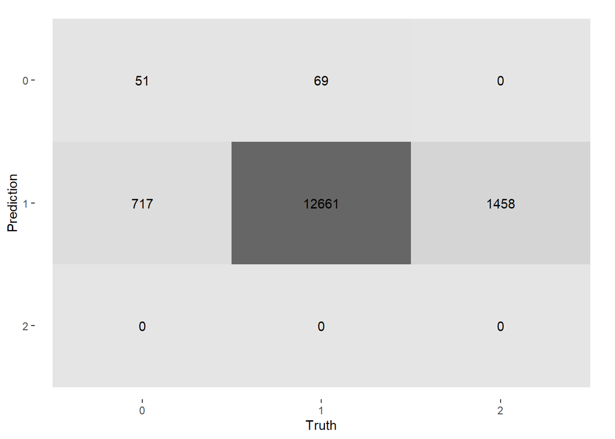

```r
pred_collected_en %>%
  conf_mat(truth, pred) %>%
  autoplot(type = "heatmap")
```

So, clearly the model is quite good at predicting class 1, as it had an accuracy is pretty close to 100% when looking at class 1, however this is only because it almost exclusively predicts class 1, which is the biggest of the three classes. The accuracy is in this case quite misleading, as the model performs rather poorly at what we want it do. Let’s see how the random forest performed.

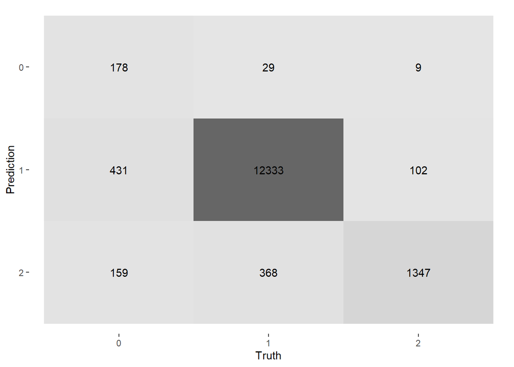

```r
set.seed(42)
pred_collected_rf <- tibble(
  truth = data_train_prep %>% pull(y),
  pred = fit_rf %>% predict(new_data = data_train_prep) %>% pull(.pred_class),
  )

pred_collected_rf %>% conf_mat(truth, pred) %>% autoplot(type = "heatmap")
```

$\frac{true\, positive}{true\, positive \,+ \,false\, positive}$

```r
round(178/(178+29+9),4) # Rounding to 4 decimals.
```

```
## [1] 0.8241
```

```r
pred_collected_rf %>% conf_mat(truth, pred) %>% summary() %>% slice(c(1,11))
```

| .metric | .estimator | .estimate |
| --- | --- | --- |
| accuracy | multiclass | 0.9265846 |
| precision | macro | 0.8338101 |

```r
set.seed(42)
data_recipe_ds <- data_train %>%
  recipe(y ~.) %>%
  step_mutate(tweet = str_replace_all(tweet, 'http\\S+\\s*|\\.|\\"|RT|amp|[:digit:]|@[:graph:]*\\s|[^[:alnum:]]', " ")) %>%
  step_tokenize(tweet, token = "tweets") %>%
  step_tokenfilter(tweet, min_times = 50) %>% # Removing tokens that appear less than 50 times.
  step_stopwords(tweet, keep = FALSE) %>%
  step_stem(tweet) %>%
  step_untokenize(tweet) %>%
  step_filter(tweet != "") %>%
  step_filter(str_length(tweet) > 3) %>%
  step_tokenize(tweet) %>%
  step_tfidf(tweet) %>%
  themis::step_downsample(y) %>%
  prep()

data_train_prep_ds <- data_recipe_ds %>% juice()
data_test_prep_ds <- data_recipe_ds %>% bake(data_test)

fit_en <- model_en %>% fit(formula = y ~., data = data_train_prep_ds) # Logistic model.

fit_rf <- model_rf %>% fit(formula = y ~., data = data_train_prep_ds) # Random forest model.

fit_xg <- model_xg %>% fit(formula = y ~., data = data_train_prep_ds) # XG Boost model.
```

Let’s inspect the confusion matrix for the predictions from the logistic model.

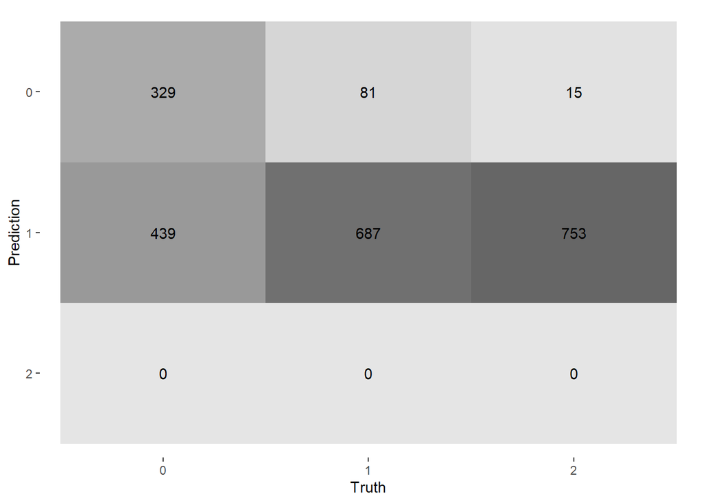

```r
set.seed(42)
pred_collected_en_ds <- tibble(
  truth = data_train_prep_ds %>% pull(y),
  pred = fit_en %>% predict(new_data = data_train_prep_ds) %>% pull(.pred_class),
  )

pred_collected_en_ds %>%
  conf_mat(truth, pred) %>%
  autoplot(type = "heatmap")
```

It clearly still does not perform too well overall, and I will therefore not be bothering with it anymore. Let’s see how the random forest model did.

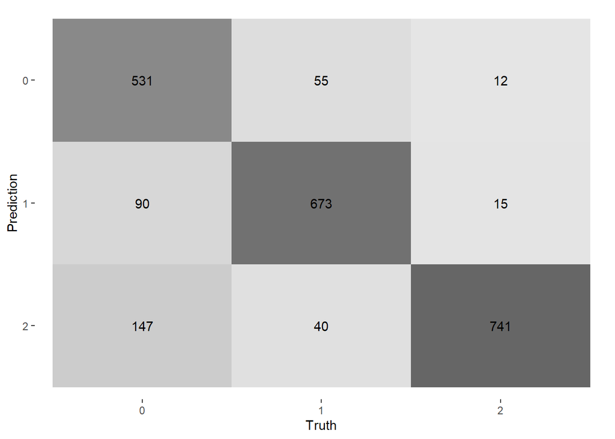

```r
set.seed(42)
pred_collected_rf_ds <- tibble(
  truth = data_train_prep_ds %>% pull(y),
  pred = fit_rf %>% predict(new_data = data_train_prep_ds) %>% pull(.pred_class),
  )

pred_collected_rf_ds %>% conf_mat(truth, pred) %>% autoplot(type = "heatmap")
```

Clearly, the downsampling has helped the class 0 false negatives a lot. Let’s look at the XG Boosted Tree model.

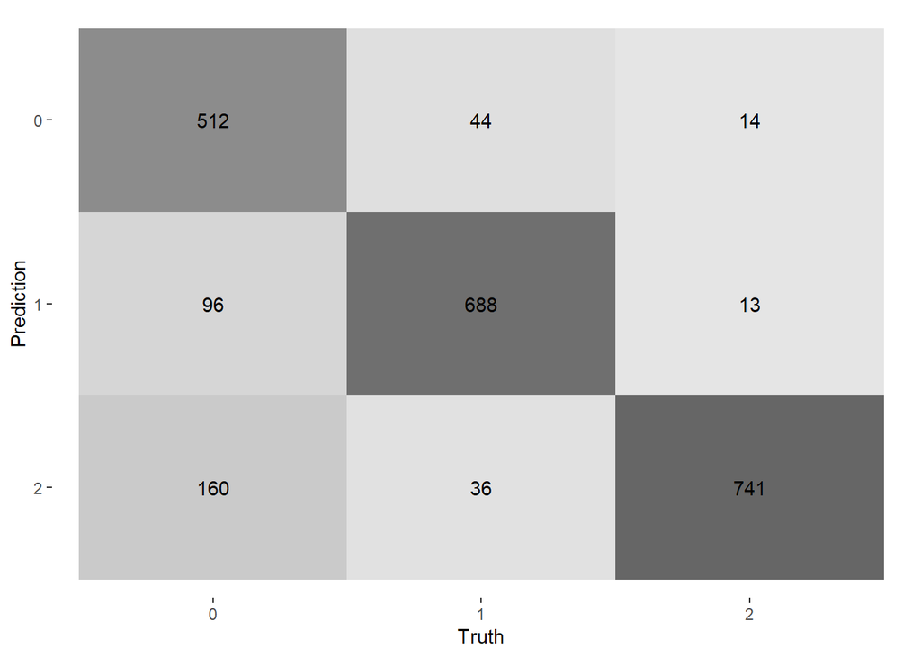

```r
set.seed(42)
pred_collected_xg_ds <- tibble(
  truth = data_train_prep_ds %>% pull(y),
  pred = fit_xg %>% predict(new_data = data_train_prep_ds) %>% pull(.pred_class),
  )

pred_collected_xg_ds %>% conf_mat(truth, pred) %>% autoplot(type = "heatmap")
```

The XG Boosted Trees model looks very similar to the random forest. Perhaps the overall accuracy and precision of the two can provide some insights.

```r
pred_collected_rf_ds %>% conf_mat(truth,pred) %>% summary() %>% slice(c(1,11))
```

| .metric | .estimator | .estimate |
| --- | --- | --- |
| accuracy | multiclass | 0.8441840 |
| precision | macro | 0.8504966 |

The random forest model had an accuracy of 84.4% and a precision of 85%.

```r
pred_collected_xg_ds %>% conf_mat(truth, pred) %>% summary() %>% slice(c(1,11))
```

| .metric | .estimator | .estimate |
| --- | --- | --- |
| accuracy | multiclass | 0.8424479 |
| precision | macro | 0.8507682 |

The XG Boosted Tress model is almost the same. To attempt to improve the results I run the two tree based models again, using PCA to reduce the dimensions of the data in the recipe.

```r
set.seed(42)
data_recipe_ds_pca <- data_train %>%
  recipe(y ~.) %>%
  step_mutate(tweet = str_replace_all(tweet, 'http\\S+\\s*|\\.|\\"|RT|amp|[:digit:]|@[:graph:]*\\s|[^[:alnum:]]', " ")) %>%
  step_tokenize(tweet, token = "tweets") %>%
  step_tokenfilter(tweet, min_times = 50) %>% # Removing tokens that appear less than 50 times.
  step_stopwords(tweet, keep = FALSE) %>%
  step_stem(tweet) %>%
  step_untokenize(tweet) %>%
  step_filter(tweet != "") %>%
  step_filter(str_length(tweet) > 3) %>%
  step_tokenize(tweet) %>%
  step_tfidf(tweet) %>%
  step_pca(all_predictors()) %>% # Applying PCA to all predictors.
  themis::step_downsample(y) %>%
  prep()

data_train_prep_ds_pca <- data_recipe_ds_pca %>% juice()
data_test_prep_ds_pca <- data_recipe_ds_pca %>% bake(data_test)

fit_rf <- model_rf %>% fit(formula = y ~., data = data_train_prep_ds_pca) # Random forest model.

fit_xg <- model_xg %>% fit(formula = y ~., data = data_train_prep_ds_pca) # XG Boost model.

pred_collected_rf_ds_pca <- tibble( # Random forest PCA reduced.
  truth = data_train_prep_ds_pca %>% pull(y),
  pred = fit_rf %>% predict(new_data = data_train_prep_ds_pca) %>% pull(.pred_class),
  )

pred_collected_xg_ds_pca <- tibble( # XG Boosted trees PCA reduced.
  truth = data_train_prep_ds_pca %>% pull(y),
  pred = fit_xg %>% predict(new_data = data_train_prep_ds_pca) %>% pull(.pred_class),
  )
```

Let’s revisit the metrics from before.

```r
pred_collected_rf_ds_pca %>% conf_mat(truth, pred) %>% summary() %>% slice(c(1,11))
```

| .metric | .estimator | .estimate |
| --- | --- | --- |
| accuracy | multiclass | 0.8593750 |
| precision | macro | 0.8637217 |

The accuracy and precision of the model is slightly improved, indicating that the PCA helped with the model performance. How about the XG Boosted Trees model?

```r
pred_collected_xg_ds_pca %>% conf_mat(truth, pred) %>% summary() %>% slice(c(1,11))
```

| .metric | .estimator | .estimate |
| --- | --- | --- |
| accuracy | multiclass | 0.8750000 |
| precision | macro | 0.8785239 |

The XG Boosted Trees model also appears to have benefitted from the PCA. Let’s see how the predictions of the random forest look.

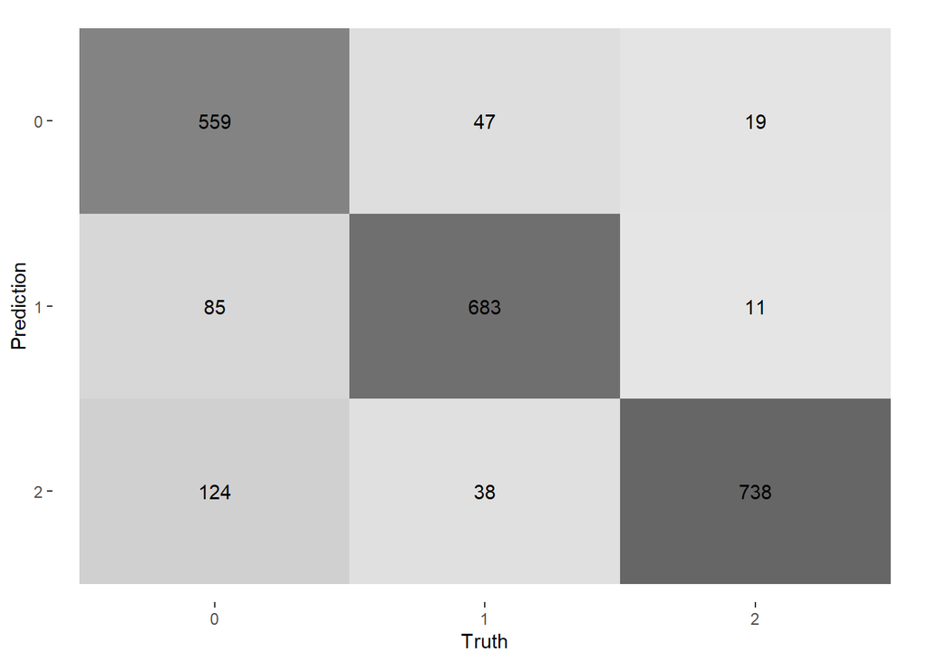

```r
pred_collected_rf_ds_pca %>% conf_mat(truth, pred) %>% autoplot(type = "heatmap")
```

The precision of class 0 for the random forest model was

```r
559/(559+47+19)
```

```
## [1] 0.8944
```

Which is very good. However it appears that the model somehow predicts some inoffensive tweets as hate speech, which is quite odd. Let’s explore the XG Boosted Trees model.

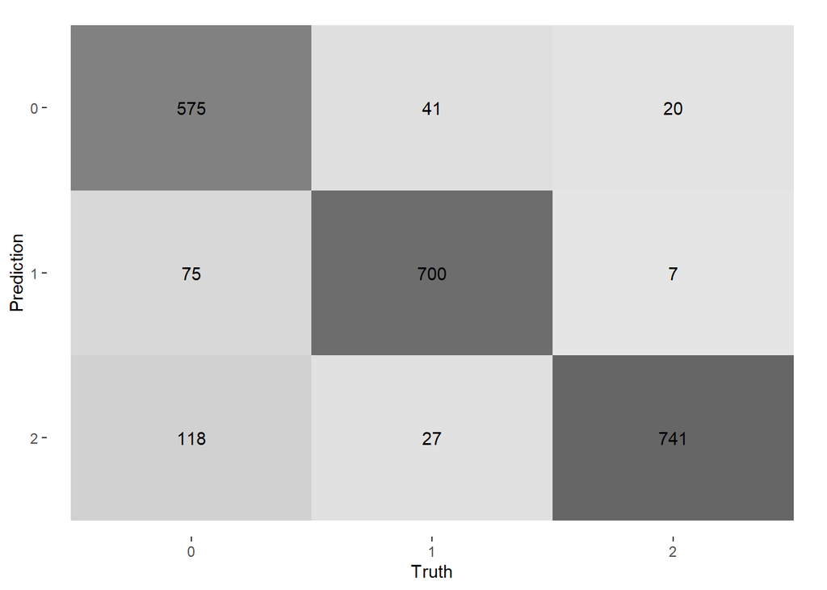

```r
pred_collected_xg_ds_pca %>% conf_mat(truth, pred) %>% autoplot(type = "heatmap")
```

I, again, calculate the class 0 precision.

```r
575/(575+41+20)
```

```
## [1] 0.9040881
```

### Test data

Both models had a precision around 90% for class 0 when predicting using the training data, however this could have be helped along by overfitting to the data. Therefore I will be simulating how the final models perform when seeing new data, through the test data. The test data for some reason is not downsampled like the training data, but perhaps training the models using downsampled data, still make them better at predicting hate speech, since it has been relatively less exposed to class 1 data. First I test the random forest model.

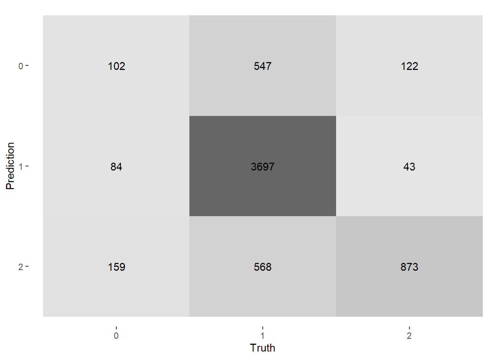

```r
set.seed(42)
pred_collected_rf_ds_test <- tibble(
  truth = data_test_prep_ds_pca %>% pull(y), # Using the test data for the true values.
  pred = fit_rf %>% predict(new_data = data_test_prep_ds_pca) %>% pull(.pred_class), # Predicting using the test data.
  )

pred_collected_rf_ds_test %>% conf_mat(truth, pred) %>% autoplot(type = "heatmap")
```

We can clearly see that the model performs quite poorly. Let’s see exactly how much worse the model is.

```r
pred_collected_rf_ds_test %>% conf_mat(truth, pred) %>% summary() %>% slice(c(1,11))
```

| .metric | .estimator | .estimate |
| --- | --- | --- |
| accuracy | multiclass | 0.7541566 |
| precision | macro | 0.5482365 |

The precision took a particularly big hit. As the confusion matrix also indicate, the class 0 precision is extremely poor.

```r
102/(102+547+122)
```

```
## [1] 0.1322957
```

The class 0 prediction is roughly 13%. The model expected more of the words to be used in hate speech context, which probably is caused by its training on the downsampled data. Perhaps the XG Boosted Tree model does a better job on the new data?

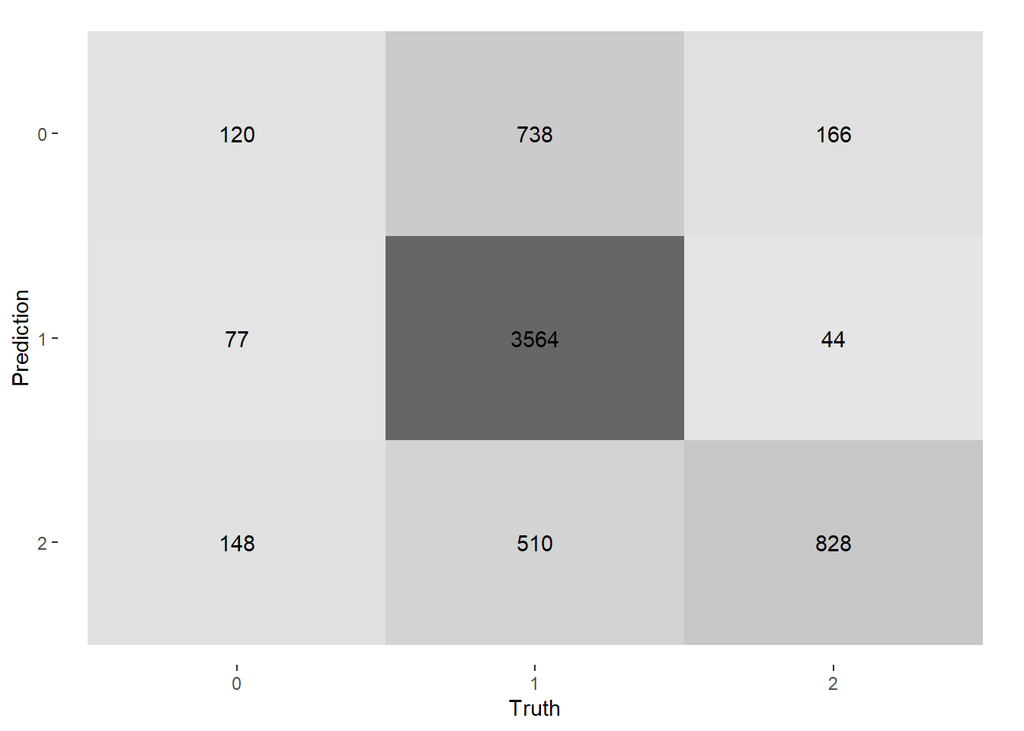

```r
set.seed(42)
pred_collected_xg_ds_test <- tibble(
  truth = data_test_prep_ds_pca %>% pull(y), # Using the test data for the true values.
  pred = fit_xg %>% predict(new_data = data_test_prep_ds_pca) %>% pull(.pred_class), # Predicting using the test data.
  )

pred_collected_xg_ds_test %>% conf_mat(truth, pred) %>% autoplot(type = "heatmap")
```

```r
pred_collected_xg_ds_test %>% conf_mat(truth, pred) %>% summary() %>% slice(c(1,11))
```

| .metric | .estimator | .estimate |
| --- | --- | --- |
| accuracy | multiclass | 0.7283293 |
| precision | macro | 0.5471841 |

Nope, not really.

### Missclassified tweets

For the bonus task of seeing which tweets are being missclassified I will be using the training data, where all was nice and well, since the downsampling probably has skewed things quite a bit, and there are less instances of missclassification to focus on with the training data.

For this task I need to find the tweets responsible for the models predictions. One way of doing this, is to create a new recipe of identical length, where the data is not reduced by PCA, such that the tweets are easily accesible.

```r
set.seed(42)
bonus_recipe <- data_train %>%
  recipe(y ~.) %>%
  step_mutate(
    tweet = str_replace_all(tweet, 'http\\S+\\s*|\\.|\\"|RT|amp|[:digit:]|@[:graph:]*\\s|[^[:alnum:]]', " ")) %>%
  step_tokenize(tweet, token = "tweets") %>%
  step_tokenfilter(tweet, min_times = 50) %>% # Removing tokens that appear less than 50 times.
  step_stopwords(tweet, keep = FALSE) %>%
  step_stem(tweet) %>%
  step_untokenize(tweet)%>% # Untokenizing the tweets again.
  step_filter(tweet != "") %>%
  step_filter(str_length(tweet) > 3) %>% # Remove tweets shorter than 2 characters.
  themis::step_downsample(y) %>%
  prep()
```

Next I juice the recipe and print 5 tweets from each class.

The recipe then needs to be juiced and saved.

```r
data_bonus <- bonus_recipe %>% juice()
data_bonus %>% group_by(y) %>% slice(1:5) # Printing the first 5 tweets per class.
```

| tweet | y |
| --- | --- |
| hate | 0 |
| t like | 0 |
| faggot | 0 |
| can make | 0 |
| bitch | 0 |
| bitch yo hate u | 1 |
| re bitch | 1 |
| get yo don t don t | 1 |
| just now like bitch | 1 |
| fuck got bitch get | 1 |

[output cut: 5 more lines]

To see which tweets were classified correctly I join the predictions made by the XG Boosted Trees model, when fitted to the pca reduced downsampled training data, since this model had the best results overall.

```r
predic <- data_bonus %>%
  cbind(pred_collected_xg_ds_pca$pred) %>%
  set_colnames(c("tweet", "true_class", "pred_class"))
```

Let’s look at some of the 61 tweets that were missclassified as hate speech.

```r
predic %>%
  filter(true_class != 0 & pred_class == 0) %>% # Tweets from class 1 or 2 where the model predicts 0.
  head(20)
```

|  | tweet | true_class | pred_class |
| --- | --- | --- | --- |
| 1 | fuck fuck fuck ass pussi | 1 | 0 |
| 2 | bitch | 1 | 0 |
| 3 | like on still bitch got | 1 | 0 |
| 4 | sai ain t bitch | 1 | 0 |
| 5 | m hoe just like lol | 1 | 0 |
| 6 | like | 1 | 0 |
| 7 | im just get can ain t shit bitch | 1 | 0 |
| 8 | hoe ass nigga | 1 | 0 |
| 9 | like bitch | 1 | 0 |
| 10 | bitch ass | 1 | 0 |

[output cut: 10 more lines]

Clearly these tweets have been reduced to just profanities and slurs. It is understandable why the model would predict them to belong to hate speech tweets. How about the supposedly inoffensive tweets that were missclassified as hate speech?

```r
predic %>%
  filter(true_class == 2 & pred_class == 0) # Tweets from class 0 that are predicted to be hate speech.
```

| tweet | true_class | pred_class |
| --- | --- | --- |
| like | 2 | 0 |
| just u | 2 | 0 |
| just | 2 | 0 |
| make | 2 | 0 |
| like trash | 2 | 0 |
| like want | 2 | 0 |
| man m | 2 | 0 |
| trash | 2 | 0 |
| time | 2 | 0 |
| trash lol | 2 | 0 |

[output cut: 10 more lines]

Generally speaking these have all become extremely short “statements”, which is probably why they are missclassified. “white” is a word often mentioned in a hate speech context, and it makes sense why it is missclassified. This is where it might be helpful to look at the surrounding words, since the context is quite important, i.e. are they painting their fence or talking about their outfit for the next klan meeting.

How about the tweets that the model was able to classify as hate speech?

```r
predic %>%
  filter(true_class == 0 & pred_class == 0) %>%
  head(40)
```

|  | tweet | true_class | pred_class |
| --- | --- | --- | --- |
| 1 | hate | 0 | 0 |
| 2 | t like | 0 | 0 |
| 3 | faggot | 0 | 0 |
| 4 | don t nigga see nigga don t see nigga yo bitch | 0 | 0 |
| 5 | go look man | 0 | 0 |
| 6 | yo faggot hate | 0 | 0 |
| 7 | now time sai | 0 | 0 |
| 8 | hate hate hate | 0 | 0 |
| 9 | re re like | 0 | 0 |
| 10 | don t want | 0 | 0 |

[output cut: 30 more lines]

For comparison I also print the correctly predicted class 1 tweets.

```r
predic %>%
  filter(true_class == 1 & pred_class == 1) %>%
  head(40)
```

|  | tweet | true_class | pred_class |
| --- | --- | --- | --- |
| 1 | bitch yo hate u | 1 | 1 |
| 2 | re bitch | 1 | 1 |
| 3 | get yo don t don t | 1 | 1 |
| 4 | just now like bitch | 1 | 1 |
| 5 | fuck got bitch get | 1 | 1 |
| 6 | got got bitch | 1 | 1 |
| 7 | fuck bitch | 1 | 1 |
| 8 | hoe don t like hoe | 1 | 1 |
| 9 | good now bitch | 1 | 1 |
| 10 | fuck bitch | 1 | 1 |

[output cut: 30 more lines]

Generally many of the tweet look similar to the class 1 tweets, but the class 0 tweets seem more centered around discussing race or sexuality, whereas the generally offensive tweets are busy talking about female dogs it seems… The model probably learns that “bitch” is usually associated with class 1, and that the racist/homophobic slurs and general talk about color is usually associated with class 0.